# ch2hw

### 2

Explain whether each scenario is a classification or regression problem, and indicate whether we are most interested in inference or prediction. Finally, provide n and p.

(a) We collect a set of data on the top 500 firms in the US. For each firm we record profit, number of employees, industry and the CEO salary. We are interested in understanding which factors affect CEO salary.

- This is a regression problem with n = 500 and p = 3. (target var is salary)

(b) We are considering launching a new product and wish to know whether it will be a success or a failure. We collect data on 20 similar products that were previously launched. For each prod- uct we have recorded whether it was a success or failure, price charged for the product, marketing budget, competition price, and ten other variables.

- This is a classification problem with n = 20 and p = 13. (target var is success/failure)

(c) We are interested in predicting the % change in the USD/Euro exchange rate in relation to the weekly changes in the world stock markets. Hence we collect weekly data for all of 2012. For each week we record the % change in the USD/Euro, the % change in the US market, the % change in the British market, and the % change in the German market.

- This is a regression problem with n = 52 and p = 3. (target var is % change in USD/Euro)

### 5

What are the advantages and disadvantages of a very flexible (versus a less flexible) approach for regression or classification? Under what circumstances might a more flexible approach be preferred to a less flexible approach? When might a less flexible approach be preferred?

- Advantages of a flexible approach are that it can fit a wider range of possible shapes of the data. Disadvantages are that it can overfit the data and be more computationally expensive. A more flexible approach might be preferred when the data is more complex and a less flexible approach might be preferred when the data is more simple (i.e. non-linear vs linear relationships).

### 6

Describe the differences between a parametric and a non-parametric statistical learning approach. What are the advantages of a parametric approach to regression or classification (as opposed to a non-parametric approach)? What are its disadvantages?

- Parametric statistical learning approaches assume a functional form for f(X) and estimate the parameters of that function. Non-parametric statistical learning approaches do not assume a functional form for f(X) and instead estimate f(X) directly from the data. The advantages of a parametric approach are that it is simpler and more interpretable. The disadvantages are that it can lead to a poor fit if the functional form is not correct.
- Example of parametric approach: linear regression
- Example of non-parametric approach: k-nearest neighbors or SVM

### 8

This exercise relates to the College data set, which can be found in the file College.csv on the book website. It contains a number of variables for 777 different universities and colleges in the US.

(a) Use the pd.read_csv() function to read the data into Python. Call the loaded data college. Make sure that you have the directory set to the correct location for the data.

```python
import pandas as pd
import numpy as np
import matplotlib.pyplot as plt
```

```python
college_df = pd.read_csv('data/College.csv')
college_df
```

|  | Unnamed: 0 | Private | Apps | Accept | Enroll | Top10perc | Top25perc | F.Undergrad | P.Undergrad | Outstate | Room.Board | Books | Personal | PhD | Terminal | S.F.Ratio | perc.alumni | Expend | Grad.Rate |
| --- | --- | --- | --- | --- | --- | --- | --- | --- | --- | --- | --- | --- | --- | --- | --- | --- | --- | --- | --- |
| 0 | Abilene Christian University | Yes | 1660 | 1232 | 721 | 23 | 52 | 2885 | 537 | 7440 | 3300 | 450 | 2200 | 70 | 78 | 18.1 | 12 | 7041 | 60 |
| 1 | Adelphi University | Yes | 2186 | 1924 | 512 | 16 | 29 | 2683 | 1227 | 12280 | 6450 | 750 | 1500 | 29 | 30 | 12.2 | 16 | 10527 | 56 |
| 2 | Adrian College | Yes | 1428 | 1097 | 336 | 22 | 50 | 1036 | 99 | 11250 | 3750 | 400 | 1165 | 53 | 66 | 12.9 | 30 | 8735 | 54 |
| 3 | Agnes Scott College | Yes | 417 | 349 | 137 | 60 | 89 | 510 | 63 | 12960 | 5450 | 450 | 875 | 92 | 97 | 7.7 | 37 | 19016 | 59 |
| 4 | Alaska Pacific University | Yes | 193 | 146 | 55 | 16 | 44 | 249 | 869 | 7560 | 4120 | 800 | 1500 | 76 | 72 | 11.9 | 2 | 10922 | 15 |
| ... | ... | ... | ... | ... | ... | ... | ... | ... | ... | ... | ... | ... | ... | ... | ... | ... | ... | ... | ... |
| 772 | Worcester State College | No | 2197 | 1515 | 543 | 4 | 26 | 3089 | 2029 | 6797 | 3900 | 500 | 1200 | 60 | 60 | 21.0 | 14 | 4469 | 40 |
| 773 | Xavier University | Yes | 1959 | 1805 | 695 | 24 | 47 | 2849 | 1107 | 11520 | 4960 | 600 | 1250 | 73 | 75 | 13.3 | 31 | 9189 | 83 |
| 774 | Xavier University of Louisiana | Yes | 2097 | 1915 | 695 | 34 | 61 | 2793 | 166 | 6900 | 4200 | 617 | 781 | 67 | 75 | 14.4 | 20 | 8323 | 49 |
| 775 | Yale University | Yes | 10705 | 2453 | 1317 | 95 | 99 | 5217 | 83 | 19840 | 6510 | 630 | 2115 | 96 | 96 | 5.8 | 49 | 40386 | 99 |
| 776 | York College of Pennsylvania | Yes | 2989 | 1855 | 691 | 28 | 63 | 2988 | 1726 | 4990 | 3560 | 500 | 1250 | 75 | 75 | 18.1 | 28 | 4509 | 99 |

777 rows × 19 columns

(b) Look at the data used in the notebook by creating and running a new cell with just the code college in it. You should notice that the first column is just the name of each university in a column named something like Unnamed: 0. We don’t really want pandas to treat this as data. However, it may be handy to have these names for later. Try the following commands and similarly look at the resulting data frames:

```
college2 = pd.read_csv('College.csv', index_col =0)
college3 = college.rename ({'Unnamed: 0': 'College '}, axis =1)
college3 = college3.set_index('College ')
```

```python
college2 = pd.read_csv('data/College.csv', index_col =0)
college3 = college2.rename ({'Unnamed: 0': 'College'}, axis =1)
# college3 = college3.set_index('College')
```

This has used the first column in the file as an index for the data frame. This means that pandas has given each row a name corresponding to the appropriate university. Now you should see that the first data column is Private. Note that the names of the colleges appear on the left of the table. We also introduced a new python object above: a dictionary, which is specified by (key, value) pairs. Keep your modified version of the data with the following:

```
college = college3
```

```python
college = college3
college
```

|  | Private | Apps | Accept | Enroll | Top10perc | Top25perc | F.Undergrad | P.Undergrad | Outstate | Room.Board | Books | Personal | PhD | Terminal | S.F.Ratio | perc.alumni | Expend | Grad.Rate |
| --- | --- | --- | --- | --- | --- | --- | --- | --- | --- | --- | --- | --- | --- | --- | --- | --- | --- | --- |
| Abilene Christian University | Yes | 1660 | 1232 | 721 | 23 | 52 | 2885 | 537 | 7440 | 3300 | 450 | 2200 | 70 | 78 | 18.1 | 12 | 7041 | 60 |
| Adelphi University | Yes | 2186 | 1924 | 512 | 16 | 29 | 2683 | 1227 | 12280 | 6450 | 750 | 1500 | 29 | 30 | 12.2 | 16 | 10527 | 56 |
| Adrian College | Yes | 1428 | 1097 | 336 | 22 | 50 | 1036 | 99 | 11250 | 3750 | 400 | 1165 | 53 | 66 | 12.9 | 30 | 8735 | 54 |
| Agnes Scott College | Yes | 417 | 349 | 137 | 60 | 89 | 510 | 63 | 12960 | 5450 | 450 | 875 | 92 | 97 | 7.7 | 37 | 19016 | 59 |
| Alaska Pacific University | Yes | 193 | 146 | 55 | 16 | 44 | 249 | 869 | 7560 | 4120 | 800 | 1500 | 76 | 72 | 11.9 | 2 | 10922 | 15 |
| ... | ... | ... | ... | ... | ... | ... | ... | ... | ... | ... | ... | ... | ... | ... | ... | ... | ... | ... |
| Worcester State College | No | 2197 | 1515 | 543 | 4 | 26 | 3089 | 2029 | 6797 | 3900 | 500 | 1200 | 60 | 60 | 21.0 | 14 | 4469 | 40 |
| Xavier University | Yes | 1959 | 1805 | 695 | 24 | 47 | 2849 | 1107 | 11520 | 4960 | 600 | 1250 | 73 | 75 | 13.3 | 31 | 9189 | 83 |
| Xavier University of Louisiana | Yes | 2097 | 1915 | 695 | 34 | 61 | 2793 | 166 | 6900 | 4200 | 617 | 781 | 67 | 75 | 14.4 | 20 | 8323 | 49 |
| Yale University | Yes | 10705 | 2453 | 1317 | 95 | 99 | 5217 | 83 | 19840 | 6510 | 630 | 2115 | 96 | 96 | 5.8 | 49 | 40386 | 99 |
| York College of Pennsylvania | Yes | 2989 | 1855 | 691 | 28 | 63 | 2988 | 1726 | 4990 | 3560 | 500 | 1250 | 75 | 75 | 18.1 | 28 | 4509 | 99 |

777 rows × 18 columns

(c) Use the describe() method of to produce a numerical summary of the variables in the data set.

```python
college.describe()
```

|  | Apps | Accept | Enroll | Top10perc | Top25perc | F.Undergrad | P.Undergrad | Outstate | Room.Board | Books | Personal | PhD | Terminal | S.F.Ratio | perc.alumni | Expend | Grad.Rate |
| --- | --- | --- | --- | --- | --- | --- | --- | --- | --- | --- | --- | --- | --- | --- | --- | --- | --- |
| count | 777.000000 | 777.000000 | 777.000000 | 777.000000 | 777.000000 | 777.000000 | 777.000000 | 777.000000 | 777.000000 | 777.000000 | 777.000000 | 777.000000 | 777.000000 | 777.000000 | 777.000000 | 777.000000 | 777.00000 |
| mean | 3001.638353 | 2018.804376 | 779.972973 | 27.558559 | 55.796654 | 3699.907336 | 855.298584 | 10440.669241 | 4357.526384 | 549.380952 | 1340.642214 | 72.660232 | 79.702703 | 14.089704 | 22.743887 | 9660.171171 | 65.46332 |
| std | 3870.201484 | 2451.113971 | 929.176190 | 17.640364 | 19.804778 | 4850.420531 | 1522.431887 | 4023.016484 | 1096.696416 | 165.105360 | 677.071454 | 16.328155 | 14.722359 | 3.958349 | 12.391801 | 5221.768440 | 17.17771 |
| min | 81.000000 | 72.000000 | 35.000000 | 1.000000 | 9.000000 | 139.000000 | 1.000000 | 2340.000000 | 1780.000000 | 96.000000 | 250.000000 | 8.000000 | 24.000000 | 2.500000 | 0.000000 | 3186.000000 | 10.00000 |
| 25% | 776.000000 | 604.000000 | 242.000000 | 15.000000 | 41.000000 | 992.000000 | 95.000000 | 7320.000000 | 3597.000000 | 470.000000 | 850.000000 | 62.000000 | 71.000000 | 11.500000 | 13.000000 | 6751.000000 | 53.00000 |
| 50% | 1558.000000 | 1110.000000 | 434.000000 | 23.000000 | 54.000000 | 1707.000000 | 353.000000 | 9990.000000 | 4200.000000 | 500.000000 | 1200.000000 | 75.000000 | 82.000000 | 13.600000 | 21.000000 | 8377.000000 | 65.00000 |
| 75% | 3624.000000 | 2424.000000 | 902.000000 | 35.000000 | 69.000000 | 4005.000000 | 967.000000 | 12925.000000 | 5050.000000 | 600.000000 | 1700.000000 | 85.000000 | 92.000000 | 16.500000 | 31.000000 | 10830.000000 | 78.00000 |
| max | 48094.000000 | 26330.000000 | 6392.000000 | 96.000000 | 100.000000 | 31643.000000 | 21836.000000 | 21700.000000 | 8124.000000 | 2340.000000 | 6800.000000 | 103.000000 | 100.000000 | 39.800000 | 64.000000 | 56233.000000 | 118.00000 |

(d) Use the pd.plotting.scatter_matrix() function to produce a scatterplot matrix of the first columns [Top10perc, Apps, Enroll]. Recall that you can reference a list C of columns of a data frame A using A[C].

```
array([[<Axes: xlabel='Top10perc', ylabel='Top10perc'>,
        <Axes: xlabel='Apps', ylabel='Top10perc'>,
        <Axes: xlabel='Enroll', ylabel='Top10perc'>],
       [<Axes: xlabel='Top10perc', ylabel='Apps'>,
        <Axes: xlabel='Apps', ylabel='Apps'>,
        <Axes: xlabel='Enroll', ylabel='Apps'>],
       [<Axes: xlabel='Top10perc', ylabel='Enroll'>,
        <Axes: xlabel='Apps', ylabel='Enroll'>,
        <Axes: xlabel='Enroll', ylabel='Enroll'>]], dtype=object)
```

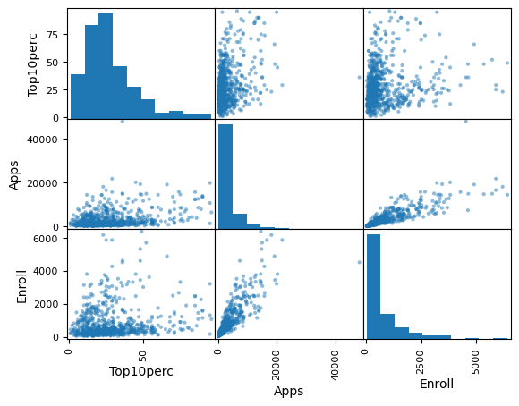

```python
pd.plotting.scatter_matrix(college[['Top10perc', 'Apps', 'Enroll']])
```

(e) Use the boxplot() method of college to produce side-by-side boxplots of Outstate versus Private.

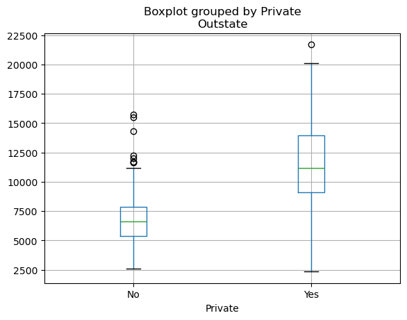

```python
college.boxplot(column = 'Outstate', by = 'Private')
```

(f) Create a new qualitative variable, called Elite, by binning the Top10perc variable into two groups based on whether or not the proportion of students coming from the top 10% of their high school classes exceeds 50%.

```
college['Elite '] = pd.cut(college['Top10perc '],
[0,0.5,1],
labels =['No', 'Yes'])
```

Use the value_counts() method of college['Elite'] to see how many elite universities there are. Finally, use the boxplot() method again to produce side-by-side boxplots of Outstate versus Elite.

```python
# college['Top10perc_ratio'] = college['Top10perc'] / college['Enroll']
# college['Elite'] = college['Top10perc_ratio'] > 0.5
# # change to yes or no
# college['Elite'] = college['Elite'].replace({True: 'Yes', False: 'No'})
```

```python
college['Elite'].value_counts()
```

[output not shown]

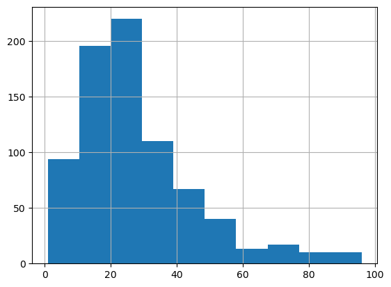

```python
college['Top10perc'].hist()
```

```python
# use pandas cut to create a binary variable, Elite, which is True if the proportion of students coming from the top 10% of their high school classes exceeds 50%.
college['Is_Elite'] = pd.cut(college['Top10perc'], [0,50,100], labels = [False, True])
college['Is_Elite'].value_counts()
```

```
False    699
True      78
Name: Is_Elite, dtype: int64
```

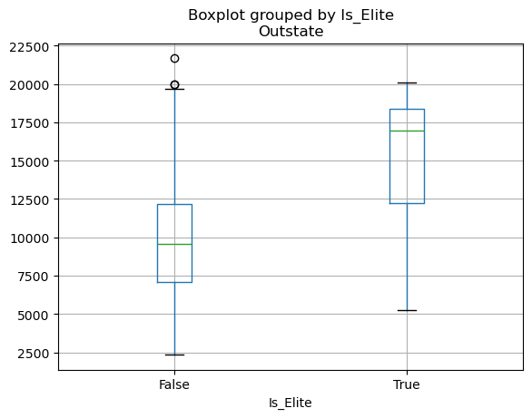

```python
college.boxplot(column = 'Outstate', by = 'Is_Elite')
```

(g) Use the plot.hist() method of college to produce some histograms with differing numbers of bins for a few of the quantitative variables. The command plt.subplots(2, 2) may be useful: it will divide the plot window into four regions so that four plots can be made simultaneously. By changing the arguments you can divide the screen up in other combinations.

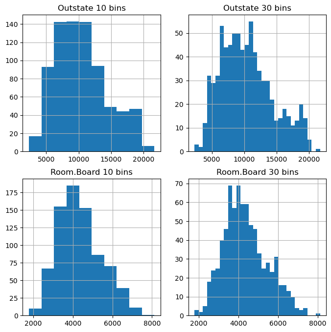

```python
fig, ax = plt.subplots(2,2)
# change size
fig.set_size_inches(8,8)
college['Outstate'].hist(ax = ax[0,0], bins = 10)
college['Outstate'].hist(ax = ax[0,1], bins = 30)
college['Room.Board'].hist(ax = ax[1,0], bins = 10)
college['Room.Board'].hist(ax = ax[1,1], bins = 30)
# set titles
ax[0,0].set_title('Outstate 10 bins')
ax[0,1].set_title('Outstate 30 bins')
ax[1,0].set_title('Room.Board 10 bins')
ax[1,1].set_title('Room.Board 30 bins')
plt.show()
```

(h) Continue exploring the data, and provide a brief summary of what you discover.

```python
college['Estimated_Total_Cost'] = college['Outstate'] + college['Room.Board'] + college['Books'] + college['Personal']
college['Acceptance_Rate'] = college['Accept'] / college['Apps']
college['Spend_to_Cost_Ratio'] = college['Expend'] / college['Estimated_Total_Cost'] # < 1 means they spend less than they take in
```

```
<BarContainer object of 10 artists>
```

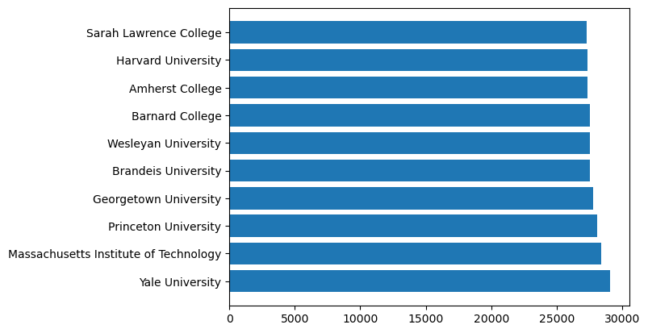

```python
# show top 10 colleges with highest Estimated Total Cost
highest_cost_top10 = college.sort_values('Estimated_Total_Cost', ascending = False).head(10)
# plot top 10 colleges with highest Estimated Total Cost, name and Estimated Total Cost, horizontal bar chart
plt.barh(highest_cost_top10.index, highest_cost_top10['Estimated_Total_Cost'])
```

The above table shows the top 10 most expensive total cost colleges in the dataset. Unsurprisingly the top 10 has multiple Ivy League schools.

```
<BarContainer object of 10 artists>
```

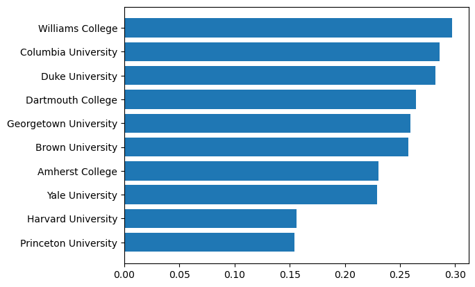

```python
# show colleges with lowest Acceptance Rate
acceptance_bottom10 = college.sort_values('Acceptance_Rate').head(10)
# plot colleges with lowest Acceptance Rate, name and Acceptance Rate, horizontal bar chart
plt.barh(acceptance_bottom10.index, acceptance_bottom10['Acceptance_Rate'])
```

Acceptance rates sort of line up with highest cost.

```
<BarContainer object of 10 artists>
```

[output not shown]

[output not shown]

[output cut: 114 more lines]

[output not shown]

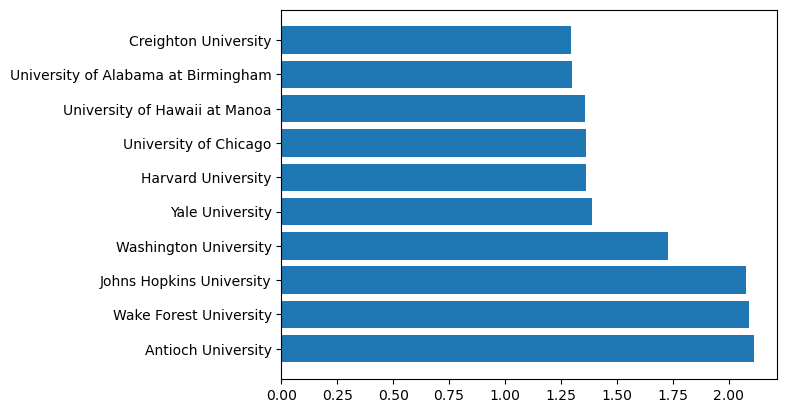

```python
# show colleges with highest Spend to Cost Ratio
spend_to_cost_top10 = college.sort_values('Spend_to_Cost_Ratio', ascending = False).head(10)
# plot colleges with highest Spend to Cost Ratio, name and Spend to Cost Ratio, horizontal bar chart
plt.barh(spend_to_cost_top10.index, spend_to_cost_top10['Spend_to_Cost_Ratio'])
```

A higher spend to cost ratio indicates that a college is spending more money per student. These would be the schools you would probably want to go to if you want to get the most bang for your buck.

```
<BarContainer object of 10 artists>
```

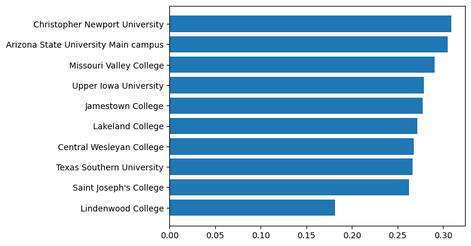

```python
# show colleges with lowest Spend to Cost Ratio
spend_to_cost_bottom10 = college.sort_values('Spend_to_Cost_Ratio').head(10)
# plot colleges with lowest Spend to Cost Ratio, name and Spend to Cost Ratio, horizontal bar chart
plt.barh(spend_to_cost_bottom10.index, spend_to_cost_bottom10['Spend_to_Cost_Ratio'])
```

The bottom 10 schools in terms of spend to cost ratio would be the schools you would want to avoid if you want to have a worthwhile investment.

### 9

This exercise involves the Auto data set studied in the lab. Make sure that the missing values have been removed from the data.

```python
auto_data = pd.read_csv('data/Auto.csv')
auto_data['horsepower'] = pd.to_numeric(auto_data['horsepower'], errors = 'coerce')
auto_data.isna().sum()
```

```
mpg             0
cylinders       0
displacement    0
horsepower      5
weight          0
acceleration    0
year            0
origin          0
name            0
dtype: int64
```

```python
auto_data.dropna(inplace = True)
```

(a) Which of the predictors are quantitative, and which are quali- tative?

```python
auto_data.dtypes
```

```
mpg             float64
cylinders         int64
displacement    float64
horsepower      float64
weight            int64
acceleration    float64
year              int64
origin            int64
name             object
dtype: object
```

```python
auto_data.describe()
```

|  | mpg | cylinders | displacement | horsepower | weight | acceleration | year | origin |
| --- | --- | --- | --- | --- | --- | --- | --- | --- |
| count | 392.000000 | 392.000000 | 392.000000 | 392.000000 | 392.000000 | 392.000000 | 392.000000 | 392.000000 |
| mean | 23.445918 | 5.471939 | 194.411990 | 104.469388 | 2977.584184 | 15.541327 | 75.979592 | 1.576531 |
| std | 7.805007 | 1.705783 | 104.644004 | 38.491160 | 849.402560 | 2.758864 | 3.683737 | 0.805518 |
| min | 9.000000 | 3.000000 | 68.000000 | 46.000000 | 1613.000000 | 8.000000 | 70.000000 | 1.000000 |
| 25% | 17.000000 | 4.000000 | 105.000000 | 75.000000 | 2225.250000 | 13.775000 | 73.000000 | 1.000000 |
| 50% | 22.750000 | 4.000000 | 151.000000 | 93.500000 | 2803.500000 | 15.500000 | 76.000000 | 1.000000 |
| 75% | 29.000000 | 8.000000 | 275.750000 | 126.000000 | 3614.750000 | 17.025000 | 79.000000 | 2.000000 |
| max | 46.600000 | 8.000000 | 455.000000 | 230.000000 | 5140.000000 | 24.800000 | 82.000000 | 3.000000 |

It appears that all of the predictors are quantitative except for name. An argument could be made that year is qualitative as well. I am unsure about the origin variable.

(b) What is the range of each quantitative predictor? You can an- swer this using the min() and max() methods in numpy.

```python
print('mpg range: {}'.format(auto_data['mpg'].max() - auto_data['mpg'].min()))
print('cylinders range: {}'.format(auto_data['cylinders'].max() - auto_data['cylinders'].min()))
print('displacement range: {}'.format(auto_data['displacement'].max() - auto_data['displacement'].min()))
print('horsepower range: {}'.format(auto_data['horsepower'].max() - auto_data['horsepower'].min()))
print('weight range: {}'.format(auto_data['weight'].max() - auto_data['weight'].min()))
print('acceleration range: {}'.format(auto_data['acceleration'].max() - auto_data['acceleration'].min()))
print('year range: {}'.format(auto_data['year'].max() - auto_data['year'].min()))
```

```
mpg range: 37.6
cylinders range: 5
displacement range: 387.0
horsepower range: 184.0
weight range: 3527
acceleration range: 16.8
year range: 12
```

(c) What is the mean and standard deviation of each quantitative predictor?

```python
print('mpg mean: {:.2f}, std: {:.2f}'.format(auto_data['mpg'].mean(), auto_data['mpg'].std()))
print('cylinders mean: {:.2f}, std: {:.2f}'.format(auto_data['cylinders'].mean(), auto_data['cylinders'].std()))
print('displacement mean: {:.2f}, std: {:.2f}'.format(auto_data['displacement'].mean(), auto_data['displacement'].std()))
print('horsepower mean: {:.2f}, std: {:.2f}'.format(auto_data['horsepower'].mean(), auto_data['horsepower'].std()))
print('weight mean: {:.2f}, std: {:.2f}'.format(auto_data['weight'].mean(), auto_data['weight'].std()))
print('acceleration mean: {:.2f}, std: {:.2f}'.format(auto_data['acceleration'].mean(), auto_data['acceleration'].std()))
print('year mean: {:.2f}, std: {:.2f}'.format(auto_data['year'].mean(), auto_data['year'].std()))
```

```
mpg mean: 23.45, std: 7.81
cylinders mean: 5.47, std: 1.71
displacement mean: 194.41, std: 104.64
horsepower mean: 104.47, std: 38.49
weight mean: 2977.58, std: 849.40
acceleration mean: 15.54, std: 2.76
year mean: 75.98, std: 3.68
```

(d) Now remove the 10th through 85th observations. What is the range, mean, and standard deviation of each predictor in the subset of the data that remains?

```python
# remove the 10th through 85th observations
auto_data.drop(auto_data.index[9:85], inplace = True)
print('mpg range: {}, mean: {:.2f}, std: {:.2f}'.format(auto_data['mpg'].max() - auto_data['mpg'].min(), auto_data['mpg'].mean(), auto_data['mpg'].std()))
print('cylinders range: {}, mean: {:.2f}, std: {:.2f}'.format(auto_data['cylinders'].max() - auto_data['cylinders'].min(), auto_data['cylinders'].mean(), auto_data['cylinders'].std()))
print('displacement range: {}, mean: {:.2f}, std: {:.2f}'.format(auto_data['displacement'].max() - auto_data['displacement'].min(), auto_data['displacement'].mean(), auto_data['displacement'].std()))
print('horsepower range: {}, mean: {:.2f}, std: {:.2f}'.format(auto_data['horsepower'].max() - auto_data['horsepower'].min(), auto_data['horsepower'].mean(), auto_data['horsepower'].std()))
print('weight range: {}, mean: {:.2f}, std: {:.2f}'.format(auto_data['weight'].max() - auto_data['weight'].min(), auto_data['weight'].mean(), auto_data['weight'].std()))
print('acceleration range: {}, mean: {:.2f}, std: {:.2f}'.format(auto_data['acceleration'].max() - auto_data['acceleration'].min(), auto_data['acceleration'].mean(), auto_data['acceleration'].std()))
print('year range: {}, mean: {:.2f}, std: {:.2f}'.format(auto_data['year'].max() - auto_data['year'].min(), auto_data['year'].mean(), auto_data['year'].std()))
```

```
mpg range: 35.6, mean: 24.40, std: 7.87
cylinders range: 5, mean: 5.37, std: 1.65
displacement range: 387.0, mean: 187.24, std: 99.68
horsepower range: 184.0, mean: 100.72, std: 35.71
weight range: 3348, mean: 2935.97, std: 811.30
acceleration range: 16.3, mean: 15.73, std: 2.69
year range: 12, mean: 77.15, std: 3.11
```

(e) Using the full data set, investigate the predictors graphically, using scatterplots or other tools of your choice. Create some plots highlighting the relationships among the predictors. Comment on your findings.

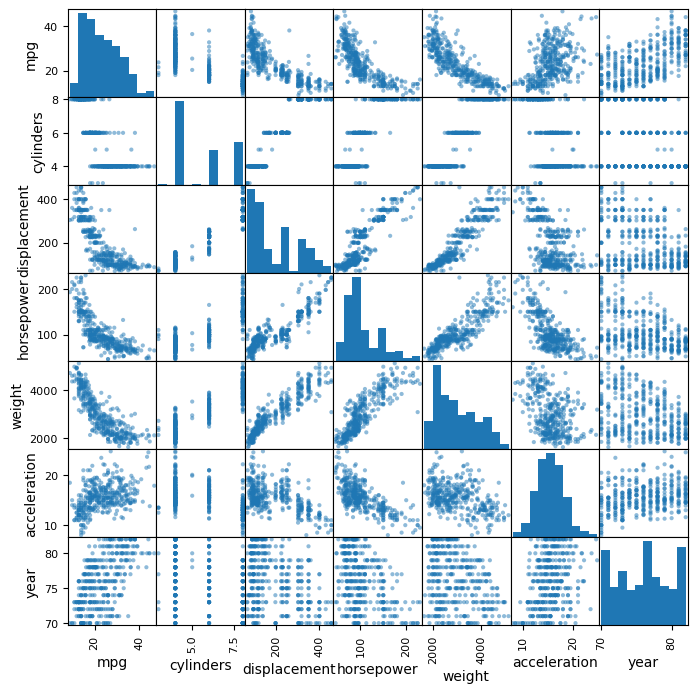

```python
auto_data = pd.read_csv('data/Auto.csv')
auto_data['horsepower'] = pd.to_numeric(auto_data['horsepower'], errors = 'coerce')
auto_data.dropna(inplace = True)
# correlation matrix
from pandas.plotting import scatter_matrix
scatter_matrix(auto_data[['mpg', 'cylinders', 'displacement', 'horsepower', 'weight', 'acceleration', 'year']], figsize = (8,8));
```

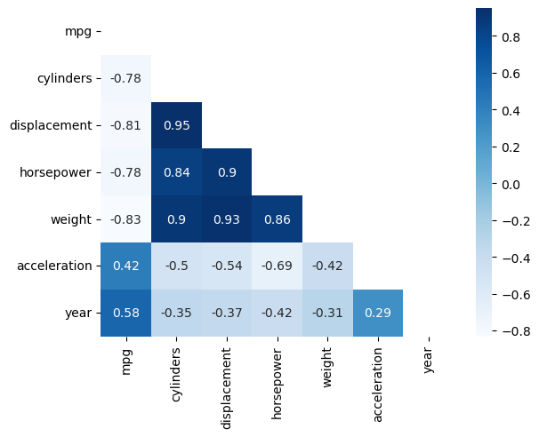

```python
# heatmap
# %pip install seaborn uncomment to install seaborn
import seaborn as sns
# use absolute value of correlation
corr = auto_data[['mpg', 'cylinders', 'displacement', 'horsepower', 'weight', 'acceleration', 'year']].corr()#.abs()
# mask upper triangle
mask = np.zeros_like(corr)
mask[np.triu_indices_from(mask)] = True
# plot heatmap
sns.heatmap(corr, mask = mask, annot = True, cmap = 'Blues');
```

(f) Suppose that we wish to predict gas mileage (mpg) on the basis of the other variables. Do your plots suggest that any of the other variables might be useful in predicting mpg? Justify your answer.

- The most useful variables for predicting mpg would be weight, displacement, and horsepower. These variables have the strongest correlations with mpg.

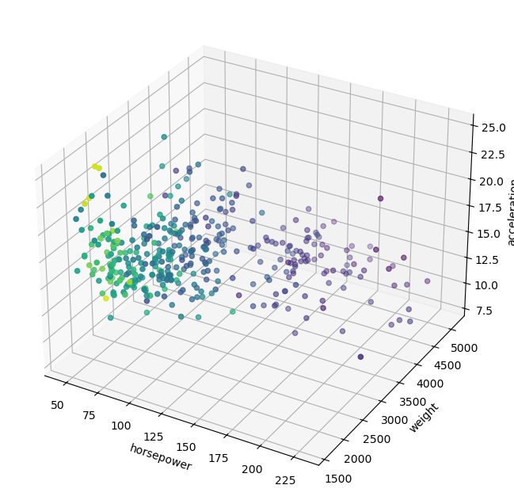

```python
#  4d plot of mpg, horsepower, weight, acceleration
fig = plt.figure(figsize = (8,8))
ax = fig.add_subplot(111, projection = '3d')
ax.scatter(auto_data['horsepower'], auto_data['weight'], auto_data['acceleration'], c = auto_data['mpg'], cmap = 'viridis')
ax.set_xlabel('horsepower')
ax.set_ylabel('weight')
ax.set_zlabel('acceleration')
plt.show()
```

```python
# %pip install plotly_express uncomment this to install plotly_express
import plotly_express as px

# 3d scatter of horsepower, weight, acceleration, colored by mpg

fig = px.scatter_3d(auto_data, x = 'horsepower', y = 'weight', z = 'acceleration', color = 'mpg')
# change to 800x800 pixels
fig.update_layout(width = 800, height = 800)
```

[output not shown]